# A Look at a New York Shooting Database

# The following is Herbs RMD for the Shooting assignment - Data Science

# New York Shootings were downloaded from the following:

Downloaded the link below given in course material on 8 Nov 2023 for NYDP Shooting Incident Data (Historic): https://data.cityofnewyork.us/api/views/833y-fsy8/rows.csv?accessType=DOWNLOAD A glimpse of the loaded data follows:

```r
url_in <- "https://data.cityofnewyork.us/api/views/833y-fsy8/rows.csv?accessType=DOWNLOAD"

gunshots <- read_csv(url_in)
summary(gunshots)
```

```
  INCIDENT_KEY        OCCUR_DATE         OCCUR_TIME           BORO           LOC_OF_OCCUR_DESC     PRECINCT
 Min.   :  9953245   Length:27312       Length:27312      Length:27312       Length:27312       Min.   :  1.00
 1st Qu.: 63860880   Class :character   Class1:hms        Class :character   Class :character   1st Qu.: 44.00
 Median : 90372218   Mode  :character   Class2:difftime   Mode  :character   Mode  :character   Median : 68.00
 Mean   :120860536                      Mode  :numeric                                          Mean   : 65.64
 3rd Qu.:188810230                                                                              3rd Qu.: 81.00
 Max.   :261190187                                                                              Max.   :123.00

 JURISDICTION_CODE LOC_CLASSFCTN_DESC LOCATION_DESC      STATISTICAL_MURDER_FLAG PERP_AGE_GROUP       PERP_SEX
 Min.   :0.0000    Length:27312       Length:27312       Mode :logical           Length:27312       Length:27312
 1st Qu.:0.0000    Class :character   Class :character   FALSE:22046             Class :character   Class :character
 Median :0.0000    Mode  :character   Mode  :character   TRUE :5266              Mode  :character   Mode  :character
 Mean   :0.3269
 3rd Qu.:0.0000
 Max.   :2.0000
 NA's   :2
  PERP_RACE         VIC_AGE_GROUP        VIC_SEX            VIC_RACE           X_COORD_CD        Y_COORD_CD
 Length:27312       Length:27312       Length:27312       Length:27312       Min.   : 914928   Min.   :125757
 Class :character   Class :character   Class :character   Class :character   1st Qu.:1000028   1st Qu.:182834
 Mode  :character   Mode  :character   Mode  :character   Mode  :character   Median :1007731   Median :194487
                                                                             Mean   :1009449   Mean   :208127
                                                                             3rd Qu.:1016838   3rd Qu.:239518
                                                                             Max.   :1066815   Max.   :271128

    Latitude       Longitude        Lon_Lat
 Min.   :40.51   Min.   :-74.25   Length:27312
 1st Qu.:40.67   1st Qu.:-73.94   Class :character
 Median :40.70   Median :-73.92   Mode  :character
 Mean   :40.74   Mean   :-73.91
 3rd Qu.:40.82   3rd Qu.:-73.88
 Max.   :40.91   Max.   :-73.70
 NA's   :10      NA's   :10
```

```r
gunshots
```

| INCIDENT_KEY | OCCUR_DATE | OCCUR_TIME | BORO | LOC_OF_OCCUR_DESC | PRECINCT | JURISDICTION_CODE | LOC_CLASSFCTN_DESC | LOCATION_DESC | STATISTICAL_MURDER_FLAG | PERP_AGE_GROUP | PERP_SEX | PERP_RACE | VIC_AGE_GROUP | VIC_SEX | VIC_RACE | X_COORD_CD | Y_COORD_CD | Latitude | Longitude | Lon_Lat |
| --- | --- | --- | --- | --- | --- | --- | --- | --- | --- | --- | --- | --- | --- | --- | --- | --- | --- | --- | --- | --- |
| 228798151 | 05/27/2021 | 21:30:00 | QUEENS | NA | 105 | 0 | NA | NA | FALSE | NA | NA | NA | 18-24 | M | BLACK | 1058925.0 | 180924.0 | 40.66296 | -73.73084 | POINT (-73.73083868899994 40.662964620000025) |
| 137471050 | 06/27/2014 | 17:40:00 | BRONX | NA | 40 | 0 | NA | NA | FALSE | NA | NA | NA | 18-24 | M | BLACK | 1005028.0 | 234516.0 | 40.81035 | -73.92494 | POINT (-73.92494232599995 40.81035186300006) |
| 147998800 | 11/21/2015 | 03:56:00 | QUEENS | NA | 108 | 0 | NA | NA | TRUE | NA | NA | NA | 25-44 | M | WHITE | 1007667.9 | 209836.5 | 40.74261 | -73.91549 | POINT (-73.91549174199997 40.74260663300004) |
| 146837977 | 10/09/2015 | 18:30:00 | BRONX | NA | 44 | 0 | NA | NA | FALSE | NA | NA | NA | <18 | M | WHITE HISPANIC | 1006537.4 | 244511.1 | 40.83778 | -73.91946 | POINT (-73.91945661499994 40.83778200300003) |
| 58921844 | 02/19/2009 | 22:58:00 | BRONX | NA | 47 | 0 | NA | NA | TRUE | 25-44 | M | BLACK | 45-64 | M | BLACK | 1024921.8 | 262189.4 | 40.88624 | -73.85291 | POINT (-73.85290950899997 40.88623791800006) |
| 219559682 | 10/21/2020 | 21:36:00 | BROOKLYN | NA | 81 | 0 | NA | NA | TRUE | NA | NA | NA | 25-44 | M | BLACK | 1004234.3 | 186461.7 | 40.67846 | -73.92795 | POINT (-73.92795224099996 40.678456718000064) |
| 85295722 | 06/17/2012 | 22:47:00 | QUEENS | NA | 114 | 0 | NA | NA | FALSE | NA | NA | NA | 25-44 | M | BLACK | 998860.0 | 214885.0 | 40.75648 | -73.94727 | POINT (-73.94726649399996 40.75648234300007) |
| 71662474 | 03/08/2010 | 19:41:00 | BROOKLYN | NA | 81 | 0 | NA | NA | TRUE | NA | NA | NA | 18-24 | M | BLACK | 1002882.9 | 192219.7 | 40.69426 | -73.93281 | POINT (-73.93280863699994 40.694264056000065) |
| 83002139 | 02/05/2012 | 05:45:00 | QUEENS | NA | 105 | 0 | NA | NA | FALSE | NA | NA | NA | 25-44 | M | BLACK | 1054366.4 | 196628.4 | 40.70611 | -73.74711 | POINT (-73.74710653899996 40.706106731000034) |
| 86437261 | 08/26/2012 | 01:10:00 | QUEENS | NA | 101 | 0 | NA | MULTI DWELL - APT BUILD | FALSE | 25-44 | M | BLACK | 25-44 | M | BLACK | 1053936.6 | 157130.4 | 40.59770 | -73.74906 | POINT (-73.74906464199995 40.59769719800005) |

[output cut: 990 more lines]

```r
write_csv(gunshots, "gunshots.csv")
```

```r
class(gunshots)
```

```
[1] "spec_tbl_df" "tbl_df"      "tbl"         "data.frame"
```

```r
gunshots_tidy <- gunshots %>%
  rename(
   date = "OCCUR_DATE",
   time = "OCCUR_TIME"
    )
```

##I only checked for missing in the MURDER FLAG col since that is the one col I am interested in. The other NA sun as location can be dealt with if needed by removal or placement in another table for anaylsis with out that location. Most the graphsd allow for missing data if that is what I was graphing.

## First peek at the data with bar charts…

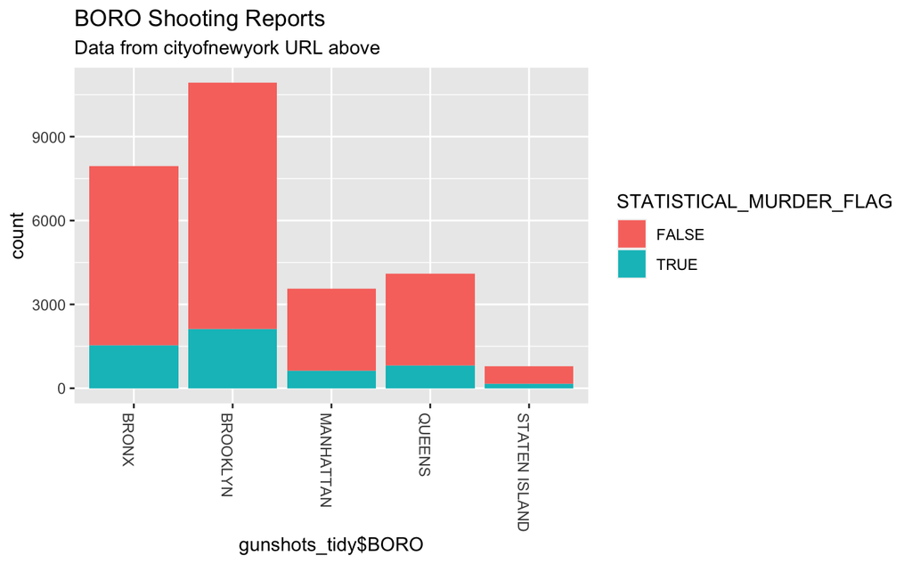

```r
gunshots_tidy |>
  ggplot(aes(x = gunshots_tidy$BORO, fill = STATISTICAL_MURDER_FLAG))+
  geom_bar()+
  theme(axis.text.x=element_text(angle = -90, hjust = 0)) +
  labs(
    title = "BORO Shooting Reports",
    subtitle="Data from cityofnewyork URL above"
  )
```